# Chapter 5: Computational Exercises

Loren

08/26/2014

```r
library(knitr)
# opts_chunk$set(bootstrap.show.code=FALSE, bootstrap.thumbnail=FALSE, bootstrap.show.message=FALSE)
library(ggplot2)
theme_set(new = theme_minimal())
#use color brewer as default discrete colors
scale_colour_discrete <- function(...) scale_color_brewer(palette="Set1", ...)
scale_fill_discrete <- function(...) scale_fill_brewer(palette="Set1", ...)
library(plyr)
# upper-case column names annoy me
sleuth.read <- function(x) {
   d <- read.csv(x)
   names(d) <- tolower(names(d))
   d
}
```

# Chapter 5: Computational Exercises

## 13. Spock Trial continued

```r
ex0513 <- sleuth.read('ascii/case0502.csv')
```

1. What is the average percentage of women from all venires?

```r
(ave.women <- mean(ex0513$percent))
```

```
## [1] 26.58
```

2. For how many of the 9 Spock judge’s venires is the percentage of women less than this grand average? All 9:

```r
with(ex0513, sum(percent < ave.women & judge == "SPOCK'S"))
```

```
## [1] 9
```

3. For how many of the venires of Spock’s judge is the percentage of women less than the average percentage for Spock’s judge?

```r
sum(with(ex0513[ex0513$judge == "SPOCK'S",], percent < mean(percent)))
```

```
## [1] 4
```

## 14. Spock - “by hand” t-test of Spock’s judge vs judge A

1. What is the pooled standard deviation?

```r
spocks.percent <- 14.62
spocks.sd <- 5.039
spocks.n <- 9
a.n <- 5
a.percent <- 34.12
a.sd <- 11.942
(sd.pooled <- sqrt(((spocks.n-1)*spocks.sd^2 + (a.n-1)*a.sd^2)/
                      (spocks.n + a.n - 2)))
```

```
## [1] 8.029
```

2. t-test

```r
df.test <- spocks.n + a.n - 2
(se <- sd.pooled * sqrt(1/spocks.n + 1/a.n)) # standard error of (a - spock)
```

```
## [1] 4.478
```

```r
(t <- (0 - (a.percent - spocks.percent)) / se)
```

```
## [1] -4.354
```

```r
2 * pt(t, df=df.test)
```

```
## [1] 0.0009378
```

3. Checking against a computer t-test:

```r
ind <- with(ex0513, judge == "SPOCK'S" | judge == "A")
t.test(percent ~ judge, data=ex0513[ind,], var.equal=T)
```

```
##
##  Two Sample t-test
##
## data:  percent by judge
## t = 4.354, df = 12, p-value = 0.0009384
## alternative hypothesis: true difference in means is not equal to 0
## 95 percent confidence interval:
##   9.74 29.26
## sample estimates:
##       mean in group A mean in group SPOCK'S
##                 34.12                 14.62
```

## 15. More Spock

1. sample variance

```r
(sv <- var(ex0513$percent))
```

```
## [1] 84.26
```

2. RSS

```r
45 * sv
```

```
## [1] 3792
```

```r
with(ex0513, sum((percent - mean(percent))^2) ) # a check
```

```
## [1] 3792
```

## 16. Spock computer F-test

```r
full <- aov(percent ~ judge, data=ex0513)
reduced <- aov(percent ~ 1, data=ex0513)
(model.comparison <- anova(full, reduced))
```

```
## Analysis of Variance Table
##
## Model 1: percent ~ judge
## Model 2: percent ~ 1
##   Res.Df  RSS Df Sum of Sq    F  Pr(>F)
## 1     39 1864
## 2     45 3792 -6     -1927 6.72 6.1e-05 ***
## ---
## Signif. codes:  0 '***' 0.001 '**' 0.01 '*' 0.05 '.' 0.1 ' ' 1
```

## 18. Fatty Acid

```r
ex0518 <- sleuth.read('ascii/ex0518.csv')
```

A model assuming six independent groups, and plots of residual vs. day.

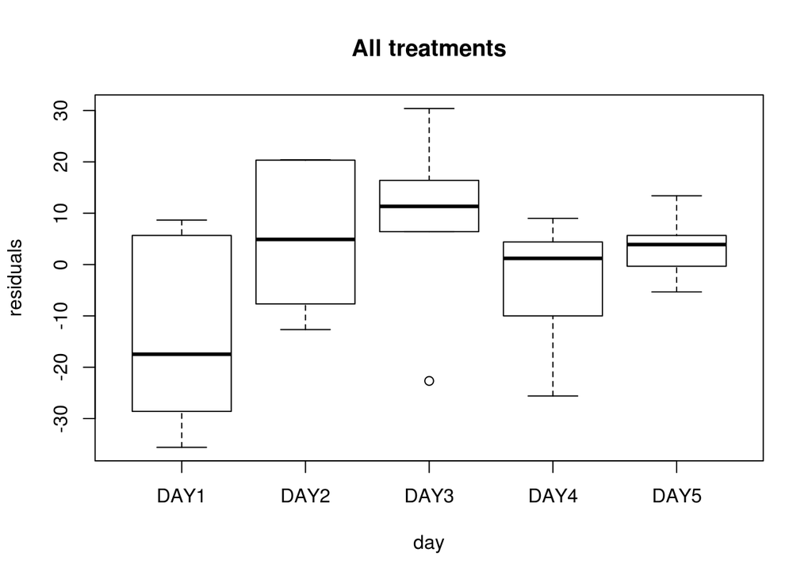

```r
six <- aov(protein ~ treatmnt, ex0518)
plot(six$residuals ~ ex0518$day, main="All treatments", ylab="residuals", xlab="day")
```

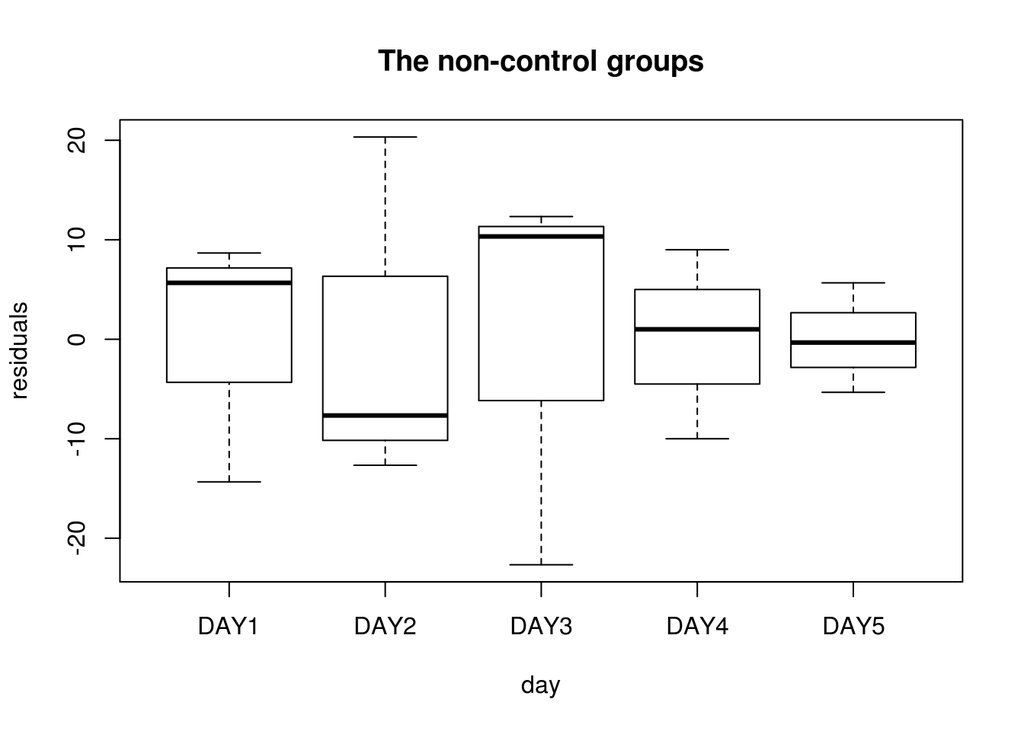

```r
with(ex0518, plot(six$residuals[ treatmnt != 'CONTROL'] ~ day[treatmnt != 'CONTROL'],
                  main="The non-control groups", ylab="residuals", xlab="day"))
```

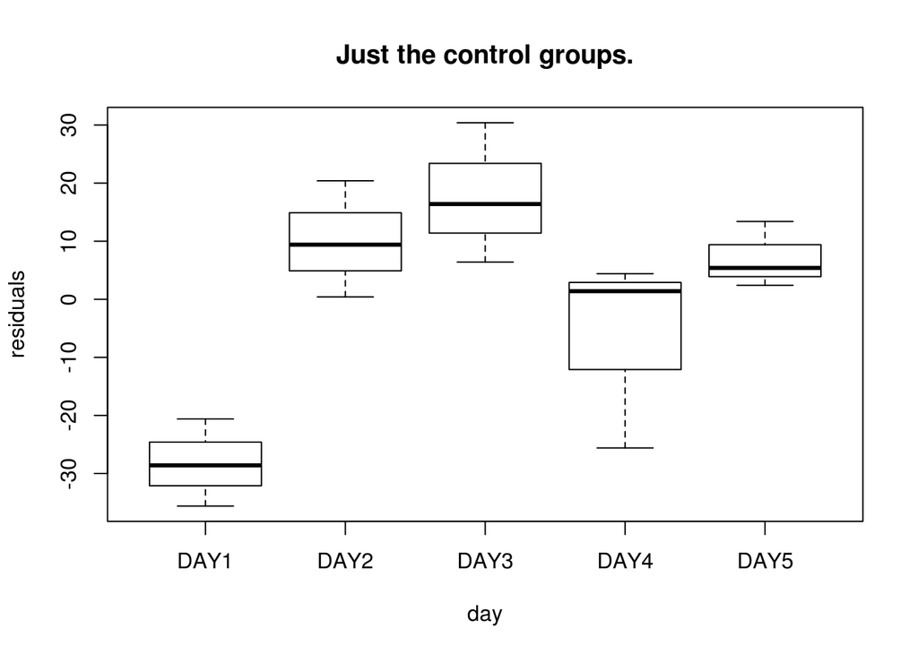

```r
with(ex0518, plot(six$residuals[ treatmnt == 'CONTROL'] ~ day[treatmnt == 'CONTROL'],
                  main="Just the control groups.", ylab="residuals", xlab="day"))
```

The residuals in the “just control” group are calculated in reference to the mean of the whole control group. So the plot shows that the observations jump around **together** from day to day. So the day seems to have an affect on the protein measurement.

The ten groups do not have equal means (shorthand for “we reject the null hypothesis that the ten groups have equal means”):

```r
ten <- aov(protein ~ trt.daygroup, ex0518)
anova(ten)
```

```
## Analysis of Variance Table
##
## Response: protein
##              Df Sum Sq Mean Sq F value  Pr(>F)
## trt.daygroup  9  11147    1239     7.8 7.2e-05 ***
## Residuals    20   3175     159
## ---
## Signif. codes:  0 '***' 0.001 '**' 0.01 '*' 0.05 '.' 0.1 ' ' 1
```

The means of the control group change from day to day: (Why are the two p-values different?)

```r
anova(ten, six)
```

```
## Analysis of Variance Table
##
## Model 1: protein ~ trt.daygroup
## Model 2: protein ~ treatmnt
##   Res.Df  RSS Df Sum of Sq    F Pr(>F)
## 1     20 3175
## 2     24 7100 -4     -3925 6.18 0.0021 **
## ---
## Signif. codes:  0 '***' 0.001 '**' 0.01 '*' 0.05 '.' 0.1 ' ' 1
```

```r
anova(aov(protein ~ day, data=subset(ex0518, treatmnt=='CONTROL')))
```

```
## Analysis of Variance Table
##
## Response: protein
##           Df Sum Sq Mean Sq F value Pr(>F)
## day        4   3925     981    8.08 0.0036 **
## Residuals 10   1215     121
## ---
## Signif. codes:  0 '***' 0.001 '**' 0.01 '*' 0.05 '.' 0.1 ' ' 1
```

## 19. Cavity Size and Use - TODO - don’t understand this one

```r
species <- c('mouse', 'pinyon mouse', "Bewick's wren", 'mountain bluebird',
             'ash-throated flycatcher', 'plain titmouse', 'northern flicker',
             'western screech owl', 'american kestrel')
n <- c(127,44,24,41,18,16,11,7,6)
mn <- c(7.347,7.368,7.418,7.487,7.563,7.568,8.214,8.272,8.297)
sample.sd <- c(.4979,.4235,.3955,.3183,.3111,.4649,.2963,.3242,.5842)
ex0519 <- data.frame(species, n, mn, sample.sd)
```

1. Compute the pooled estimate of variance.

```r
(s2p <- with(ex0519, weighted.mean(sample.sd^2, n - 1))) # see pg. 120-121
```

```
## [1] 0.1919
```

2. F-test

```r
extra.df <- (9-1)
ssw <- with(ex0519, sample.sd^2 %*% (n-1))   # SS within groups
sst <- 0.4962^2 * (294-1)                # SS total (0.4962 is their given SD)
ssb <- sst - ssw                       # SS between groups
f <- (ssb / extra.df) / s2p
pf(f, df1 = extra.df, df2 = (294-1) - (9-1), lower.tail = F)
```

```
##           [,1]
## [1,] 5.668e-14
```

```r
sneaky.sample <- function(n, desired.sample.mean, desired.sample.sd) {
   x <- rnorm(n)
   x <- (x - mean(x)) / sd(x)
   desired.sample.sd * x + desired.sample.mean
}
require(plyr)
set.seed(5432)
fake.data <- ddply(ex0519, .(species), transform, sam = sneaky.sample(n, mn, sample.sd))
anova(aov(sam ~ species, data=fake.data))
```

```
## Analysis of Variance Table
##
## Response: sam
##            Df Sum Sq Mean Sq F value  Pr(>F)
## species     8   17.5   2.182    11.4 5.5e-14 ***
## Residuals 285   54.7   0.192
## ---
## Signif. codes:  0 '***' 0.001 '**' 0.01 '*' 0.05 '.' 0.1 ' ' 1
```

## Tufte plot of Spock data

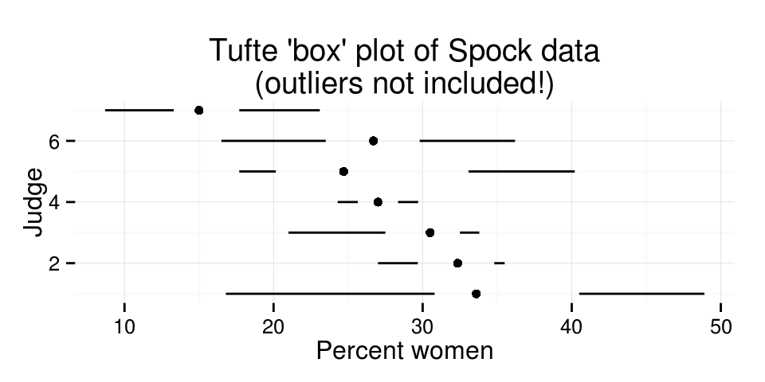

```r
c0502 <- sleuth.read('ascii/case0502.csv')
ggb <- ggplot_build(ggplot(c0502, aes(judge, percent)) + geom_boxplot())
ggplot(ggb$data[[1]]) + geom_segment(aes(x=x, y=ymin, xend=x, yend=lower)) +
   geom_segment(aes(x=x, y=upper, xend=x, yend=ymax)) +
   geom_point(aes(x=x, y=middle)) + xlab("Judge") + ylab("Percent women") +
   ggtitle("Tufte 'box' plot of Spock data\n(outliers not included!)") +
   coord_flip()
```